# Reconstructing Nestorowa Gene Binarization and STREAM State Profiles

2026-10-08

# 1. Notebook setup

This notebook reconstructs gene-expression binarization and uses the resulting cell-level profiles to derive discrete gene states for STREAM-defined cell populations. The workflow follows the statistical criteria and methods represented in the original code obtained from PROFILE GitHub page.

**Inputs (expected on disk):**

| File | Purpose |
| --- | --- |
| `nestorowa_singlecell_raw_data_taken_from_bonesis_paper.tsv` | Nestorowa gene-by-cell expression data used in the Chevalier/BoNesis workflow |
| `all_cells_distances_long.csv` | STREAM assignments and `distance_along_tree` for choosing representative cells |
| `nestorowa_singlecell_binarized_observations.csv` | Published state-by-gene discrete profiles for comparison |

## 1.1 Packages and helper functions

Load the packages used for data manipulation, distribution testing, mixture models, and plots. The `tbl_to_df()` helper converts a cell-by-gene table with a `CELL_ID` column into a matrix-like data frame with cell identifiers as row names.

```r
if (!require("pacman")) install.packages("pacman")  # Install pacman only if it is unavailable.
list.of.packages <- c("tidyverse","VennDiagram","networkD3","knitr","gridExtra","mclust","diptest","moments","magrittr")  # List the packages used by this analysis.
pacman::p_load(list.of.packages, character.only = TRUE)  # Load/install all listed packages through pacman.

tbl_to_df <- function(x){  # Define a helper to put cell identifiers into row names.
  x <- x %>% as.data.frame %>%  remove_rownames %>% column_to_rownames(var="CELL_ID")  # Convert to a data frame, remove existing row names, and promote CELL_ID.
}  # Finish defining the table-conversion helper.
rename <- dplyr::rename  # Use dplyr's rename explicitly to avoid namespace clashes.
select <- dplyr::select  # Use dplyr's select explicitly to avoid namespace clashes.

library(data.table)  # Load fast file-reading tools from data.table.
```

## 1.2 Visualize the expected input matrix with synthetic data

Before loading the real Nestorowa dataset, the following **synthetic example** illustrates the structure of the input file. These values are invented solely to demonstrate the data layout and are **not used in any subsequent analysis**.

**Expected input (genes × cells):**

- **Each row is one gene**, identified by the first column (`Gene`).
- **Each remaining column is one single cell**, identified by its cell ID (for example, `HSPC_001`).
- **Each entry is a non-negative numeric expression value**. Prior to this implementation the expected input is QC filtered and normalized data.
- The real data are read from a tab-separated file (`.tsv`). This small example is created directly in R and does not require a file.

### A. Create and display a small synthetic expression matrix

```r
pseudo_expression <- data.frame(  # Create a toy version of the input expression table.
  Gene = c("Gata1", "Spi1", "Klf1", "Meis1", "Cebpa", "Gfi1"),  # Put the six gene names in the first column.
  HSPC_001 = c(0.0, 0.8, 0.0, 4.3, 0.4, 0.2),  # Supply expression values for the first example cell.
  HSPC_002 = c(0.2, 1.1, 0.1, 3.8, 0.3, 0.0),  # Supply expression values for the second example cell.
  MPP_001 = c(0.8, 2.8, 0.2, 1.9, 1.1, 1.3),  # Supply expression values for a third example cell.
  GMP_001 = c(0.1, 4.7, 0.0, 0.5, 5.1, 3.6),  # Supply expression values for a fourth example cell.
  MEP_001 = c(5.4, 0.3, 4.6, 0.4, 0.0, 0.1),  # Supply expression values for a fifth example cell.
  check.names = FALSE  # Keep the gene and cell identifiers exactly as written.
)  # Finish constructing the synthetic genes-by-cells table.

knitr::kable(  # Render the synthetic input as a readable table in the HTML notebook.
  pseudo_expression,  # Use the example with genes in rows and cells in columns.
  digits = 1,  # Show one decimal place for the illustrative expression values.
  caption = "Synthetic input: genes in rows, cells in columns"  # Identify the orientation of the input matrix.
)  # Finish formatting the input table.
```

Synthetic input: genes in rows, cells in columns

| Gene | HSPC_001 | HSPC_002 | MPP_001 | GMP_001 | MEP_001 |
| --- | --- | --- | --- | --- | --- |
| Gata1 | 0.0 | 0.2 | 0.8 | 0.1 | 5.4 |
| Spi1 | 0.8 | 1.1 | 2.8 | 4.7 | 0.3 |
| Klf1 | 0.0 | 0.1 | 0.2 | 0.0 | 4.6 |
| Meis1 | 4.3 | 3.8 | 1.9 | 0.5 | 0.4 |
| Cebpa | 0.4 | 0.3 | 1.1 | 5.1 | 0.0 |
| Gfi1 | 0.2 | 0.0 | 1.3 | 3.6 | 0.1 |

### B. Show the orientation used by the analysis

The real import step in Section 2 **transposes** this gene-by-cell input. After transposition, each row represents a cell, each column represents a gene, and the first column is called `CELL_ID`.

```r
pseudo_numeric <- as.matrix(  # Extract the numerical portion of the synthetic matrix.
  pseudo_expression[, -1, drop = FALSE]  # Remove the Gene column, retaining all cell columns.
)  # Finish building the numeric expression matrix.
rownames(pseudo_numeric) <- pseudo_expression$Gene  # Attach gene IDs as row names before transposing.

pseudo_RNA_cells <- data.frame(  # Create the same cells-by-genes layout used downstream.
  CELL_ID = colnames(pseudo_numeric),  # Put each cell ID in the first column.
  t(pseudo_numeric),  # Transpose so that cells become rows and genes become columns.
  row.names = NULL,  # Use simple sequential row names in this display table.
  check.names = FALSE  # Preserve original gene names without modifying them.
)  # Finish constructing the transposed demonstration table.

knitr::kable(  # Display the synthetic table in the orientation required for classification.
  pseudo_RNA_cells,  # Use cells as rows and genes as numeric columns.
  digits = 1,  # Match the input table's precision.
  caption = "After transposition: cells in rows, genes in columns"  # Describe the resulting matrix layout.
)  # Finish displaying the transposed synthetic table.
```

After transposition: cells in rows, genes in columns

| CELL_ID | Gata1 | Spi1 | Klf1 | Meis1 | Cebpa | Gfi1 |
| --- | --- | --- | --- | --- | --- | --- |
| HSPC_001 | 0.0 | 0.8 | 0.0 | 4.3 | 0.4 | 0.2 |
| HSPC_002 | 0.2 | 1.1 | 0.1 | 3.8 | 0.3 | 0.0 |
| MPP_001 | 0.8 | 2.8 | 0.2 | 1.9 | 1.1 | 1.3 |
| GMP_001 | 0.1 | 4.7 | 0.0 | 0.5 | 5.1 | 3.6 |
| MEP_001 | 5.4 | 0.3 | 4.6 | 0.4 | 0.0 | 0.1 |

**Transition to the real data:** The next section performs this conversion on the actual expression file to produce `RNA_cells`. The objects beginning with `pseudo_` are illustrative only and are **not passed to the binarization or STREAM steps**.

# 2. Load and structure the expression matrix

## 2.1 Import Nestorowa expression data

**Input:** a tab-delimited table whose first column contains gene identifiers and whose remaining columns represent individual cells. The code first assigns gene names to row names, then transposes the table to orient **cells as rows and genes as columns**, as expected by the classification code. It drops the transposed gene-label row, coerces gene expression to numeric, and verifies the identifier and data types.

**Output:** `RNA_cells`, with `CELL_ID` in the first column and numeric gene-expression values in all subsequent columns. This is a reorientation/conversion step.

```r
# Load gene x cell normalized expression matrix

Chevalier_raw_data <- fread("nestorowa_singlecell_raw_data_taken_from_bonesis_paper.tsv",data.table = FALSE)  # Read the expression TSV as an ordinary data frame.
colnames(Chevalier_raw_data)[1] <- 'Gene'  # Name the initial identifier column Gene.

rownames(Chevalier_raw_data) <- Chevalier_raw_data[[1]]  # Set gene identifiers as the row names.

#Chevalier_raw_data <- Chevalier_raw_data[, -1,drop = FALSE]

dim(Chevalier_raw_data)  # Show the imported table dimensions.
```

```
## [1] 4768 1657
```

```r
head(rownames(Chevalier_raw_data))  # Inspect some gene names.
```

```
## [1] "Clec1b"        "Kdm3a"         "Coro2b"        "8430408G22Rik"
## [5] "Clec9a"        "Phf6"
```

```r
head(colnames(Chevalier_raw_data))  # Inspect the column names, including cell labels.
```

```
## [1] "Gene"       "HSPC_025"   "HSPC_031"   "HSPC_037"   "LT-HSC_001"
## [6] "HSPC_001"
```

```r
RNA_cells <- as.data.frame(  # Begin building the cells-by-genes table.
  t(Chevalier_raw_data),  # Transpose the original genes-by-cells table.
  check.names = FALSE  # Keep original identifiers without R's automatic renaming.
)  # Finish converting the transposed table to a data frame.
RNA_cells <- rownames_to_column(  # Begin storing cell IDs in an explicit column.
  RNA_cells,  # Pass the transposed data frame into rownames_to_column.
  var = "CELL_ID"  # Call the identifier column CELL_ID
)  # Finish adding the identifier column.
RNA_cells <- RNA_cells[-1,]  # Drop the transposed row corresponding to the original Gene field.
RNA_cells[-1] <- lapply(  # Begin converting every expression column to numeric.
  RNA_cells[-1],  # Select all columns except the cell identifier.
  function(x) as.numeric(trimws(x))  # Trim whitespace and coerce each gene value to numeric.
)  # Finish updating the expression columns.
dim(RNA_cells)  # Check the cells-by-genes dimensions.
```

```
## [1] 1656 4769
```

```r
head(RNA_cells[, 1:5])  # Preview IDs and the first four expression columns.
```

```
##      CELL_ID   Clec1b    Kdm3a   Coro2b 8430408G22Rik
## 2   HSPC_025 0.000000 4.891604 1.426148             0
## 3   HSPC_031 0.000000 6.877725 0.000000             0
## 4   HSPC_037 0.000000 0.000000 6.913384             0
## 5 LT-HSC_001 0.000000 0.000000 8.178374             0
## 6   HSPC_001 0.000000 0.000000 9.475577             0
## 7   HSPC_008 1.172368 8.313856 1.172368             0
```

```r
stopifnot(  # Begin data-integrity checks that stop execution if violated.
  !anyDuplicated(RNA_cells$CELL_ID),  # Require every cell identifier to be unique.
  !anyDuplicated(colnames(RNA_cells)),  # Require all column names to be unique.
  all(sapply(RNA_cells[, -1, drop = FALSE], is.numeric))  # Require every expression column to contain numeric values.
)  # Finish validating the transformed matrix.
```

# 3. Distribution-based binarization methods

RNA expression is continuous, whereas Boolean network observations require discrete gene states. The notebook uses a **distribution-dependent classification procedure**. It first characterizes the expression distribution of each gene and then applies one of two discrete classifiers.

## 3.1 Statistical and classification helper functions

**Definitions:** `0` = low-expression tail; `1` = high-expression tail; `NA` = not determined (ND). ND is different from zero expression. Genes designated `Discarded` are represented as ND.

- **Bimodality index (`BI`)**: a two-component equal-variance Gaussian-mixture separation statistic, accounting for mixture proportions.
- **Outlier-sum-style classification (`OSclass`)**: assigns 0 below `Q1 − IQR` and 1 above `Q3 + IQR`; intermediate values remain ND.
- **Bimodal classification (`BIMclass`)**: uses a two-component Gaussian mixture; expression values beyond high-confidence component-specific cutoffs are classified, while uncertain values remain ND. The code uses mixture uncertainty ≤ 0.05.

The file also defines three normalization functions (`norm_fun_lin`, `norm_fun_sig`, `norm_fun_bim`). The discrete output comes from `OSclass` or `BIMclass`.

```r
BI <- function(dataset) {  # Define the bimodality index helper.
  x <- dataset  # Use the supplied gene-expression vector.
    mc <- Mclust(na.omit(x), G = 2, modelNames = "E", verbose = FALSE)  # Fit a two-component equal-variance Gaussian mixture to available values.
    if (is.null(mc)) {  # Check whether the mixture fit is missing.
      bi <- NA  # Return a missing bimodality statistic if fitting failed.
    } else {  # Otherwise calculate the bimodality statistic from the model.
      sigma <- sqrt(mc$parameters$variance$sigmasq)  # Extract the shared component standard deviation.
      delta <- abs(diff(mc$parameters$mean))/sigma  # Compute the absolute separation between component means, in SD units.
      pi <- mc$parameters$pro[1]  # Obtain the proportion assigned to the first mixture component.
      bi <- delta * sqrt(pi*(1-pi))  # Weight mean separation by the balance of the two component proportions.
    }  # Finish the conditional fit handling.
  bi  # Return the computed bimodality index.
}  # Finish the BI helper.

#function to binarize the tails of the distribution, based on inter-quartile range (IQR), similar to methods described in teh outlier-sum statistic (Tibshirani and Hastie, 2007). Can be called with a reference dataset
OSclass <- function(exp_dataset, ref_dataset=exp_dataset) {  # Define outlier-sum-style classification, optionally against a reference.
  classif <-rep(NA,length(exp_dataset))  # Start with all observations undetermined (NA).
  q25 <- quantile(ref_dataset,0.25, na.rm = T)  # Calculate the reference distribution's 25th percentile.
  q75 <- quantile(ref_dataset,0.75, na.rm = T)  # Calculate its 75th percentile.
  IQR <- q75 - q25 #InterQuartile Range (Compute the interquartile range, Q3 minus Q1.)
  classif[exp_dataset>IQR+q75] <- 1  # Assign 1 to observations above Q3 plus the IQR.
  classif[exp_dataset<q25-IQR] <- 0  # Assign 0 to observations below Q1 minus the IQR.
  return(classif)  # Return 0/1/NA classifications.
}  # Finish the OSclass helper.

#function to to binarize bimodal distributions based on a 2-modes gaussian mixture model (with equal variances). C
BIMclass <- function(exp_dataset, ref_dataset=exp_dataset) {  # Define high-confidence classification for bimodal expression.
  mc <- Mclust(na.omit(ref_dataset), modelNames = "E", G=2, verbose = FALSE)  # Fit two equal-variance Gaussian components on reference values.
  classif <- rep(NA,length(exp_dataset))  # Initialize all query observations as undetermined.
  if (diff(mc$parameters$mean)>0){  # Handle the case where component 2 has the higher mean.
    thresh_down <- max(mc$data[mc$classification==1 & mc$uncertainty <= 0.05])  # Find the upper value assigned to low component 1 with <=5% uncertainty.
    thresh_up <- min(mc$data[mc$classification==2 & mc$uncertainty <= 0.05])  # Find the lower value assigned to high component 2 with <=5% uncertainty.
    classif[exp_dataset<=thresh_down] <- 0  # Mark values at or below the low-component cutoff as 0.
    classif[exp_dataset>=thresh_up] <- 1  # Mark values at or above the high-component cutoff as 1.
  } else if (diff(mc$parameters$mean)<0){  # Handle a fit in which component 1 has the higher mean instead.
    thresh_down <- max(mc$data[mc$classification==2 & mc$uncertainty <= 0.05])  # Find the upper low-expression cutoff from component 2.
    thresh_up <- min(mc$data[mc$classification==1 & mc$uncertainty <= 0.05])  # Find the lower high-expression cutoff from component 1.
    classif[exp_dataset<=thresh_down] <- 0  # Assign 0 for values at or below the low cutoff.
    classif[exp_dataset>=thresh_up] <- 1  # Assign 1 for values at or above the high cutoff.
  }  # Finish choosing the component ordering.
  return(classif)  # Return discrete values, with ambiguous expression left NA.
}  # Finish the BIMclass helper.

#function for normalization of zero-inflated data
norm_fun_lin <- function(xdat, reference = xdat){  # Define linear 0-to-1 normalization, not used below.
  x_proc <- (xdat-quantile(reference, 0.01, na.rm = T))/quantile(xdat-quantile(reference, 0.01, na.rm = T), 0.99, na.rm = T)  # Shift by the reference 1st percentile and scale by the 99th percentile.
  x_proc[x_proc<0] <- 0  # Clip any normalized values below zero.
  x_proc[x_proc>1] <- 1  # Clip any normalized values above one.
  x_proc  # Return the clipped normalized vector.
}  # Finish the linear normalization helper.

#function for normalization of unimodal data
norm_fun_sig <- function(xdat, reference = xdat){  # Define sigmoid normalization, not used below.
  xdat <- xdat - median(reference, na.rm = T)  # Center the observations by the reference median.
  lambda <- log(3)/mad(reference, na.rm = T)  # Set sigmoid steepness using the median absolute deviation.
  transformation <- function(x){  # Define the transformation to apply after centering.
    y <- 1/(1+exp(-lambda*x))  # Map centered values into the interval (0, 1) with a sigmoid.
    y  # Return the transformed values.
  }  # Finish defining the inner sigmoid function.
  transformation(xdat)  # Apply the sigmoid to the centered input.
}  # Finish the sigmoid normalization helper.

#function for normalization of unimodal data
norm_fun_bim <- function(xdat, reference = xdat) {  # Define mixture-posterior normalization, not used below.
  not_na_xdat <- !is.na(xdat)  # Identify query values that are not NA.
  not_na_ref <- !is.na(reference)  # Identify reference values that are not NA.
  mc <- Mclust(reference[not_na_ref], modelNames = "E", G=2, verbose = FALSE)  # Fit a two-component equal-variance Gaussian mixture to the reference.
  pred <- predict.Mclust(mc,xdat[not_na_xdat])  # Predict the model's posterior component probabilities for the query.
  normalization <- rep(NA,length(xdat))  # Initialize normalized scores with NA in all positions.
  if (diff(mc$parameters$mean)>0){  # Handle the fit where component 2 has the higher mean.
    normalization[not_na_xdat] <- pred$z[,2]  # Use the posterior probability of the high-expression component 2.
  } else if (diff(mc$parameters$mean)<0){  # Otherwise handle the fit where component 1 is higher.
    normalization[not_na_xdat] <- pred$z[,1]  # Use the posterior probability of high-expression component 1.
  }  # Finish choosing the component ordering.
  normalization  # Return high-component posterior probabilities as normalized scores.
}  # Finish the mixture normalization helper.
```

## 3.2 Classify each gene’s expression distribution

For each gene (across cells), `compute_criteria()` calculates the expression range (`Amplitude`), Hartigan dip-test p-value (`Dip`), bimodality index (`BI`), excess kurtosis (`Kurtosis`), fraction of zeros (`DropOutRate`), mean among nonzero values (`MeanNZ`), and the position of the largest density peak (`DenPeak`).

**Decision order matters:**

1. **Discarded** if the amplitude is below one-tenth of the median amplitude across genes, or the dropout rate exceeds 95%.
2. **Bimodal** if not discarded and `BI > 1.5`, `Dip < 0.05`, and excess kurtosis `< 1`.
3. **ZeroInf** if still unclassified and its density peak is below the amplitude-derived threshold.
4. **Unimodal** for everything else.

The code evaluates these rules sequentially; each later rule applies only if the gene has not yet received a category. **Output:** `criteria_cells`, one row per gene, with statistics and `Category`.

```r
#Here we compute all statistical tools and criteria needed to perform the classification of distributions in the following categories: discarded, zero-inflated, unimodal and bimodal
compute_criteria <- function(exp_dataset){  # Define the function calculating per-gene distribution statistics.
  exp_dataset <- exp_dataset %>% select(-CELL_ID)  # Remove the ID column so only gene expression remains.
  criteria <- tibble(Gene=colnames(exp_dataset), Dip=NA, BI=NA, Kurtosis=NA, DropOutRate=NA, MeanNZ=NA, DenPeak=NA, Amplitude=NA)  # Initialize a per-gene table of statistics and placeholders.

  #Compute
  pb = txtProgressBar(min = 1, max = ncol(exp_dataset), initial = 1)  # Create a console progress bar spanning all gene columns.
  for (i in 1:ncol(exp_dataset)){  # Iterate over each gene's expression values.
    x <- na.omit(unlist(exp_dataset[,i]))  # Extract this gene's nonmissing observations.
    criteria$Amplitude[i] <- max(x)-min(x)  # Compute max-minus-min expression range.

    if (criteria$Amplitude[i] !=0){  # Calculate further criteria only if the expression range is nonzero.
      criteria$Dip[i] <- dip.test(x)$p.value  # Store the Hartigan dip-test p-value for multimodality.
      criteria$BI[i] <- BI(x)  # Store the Gaussian mixture bimodality index.
      criteria$Kurtosis[i] <- kurtosis(x)-3  # Compute excess kurtosis by subtracting the normal distribution's 3.
      criteria$DropOutRate[i] <- sum(x==0)/length(x)  # Calculate the fraction of cells with zero expression.
      criteria$MeanNZ[i] <- sum(x)/sum(x!=0)  # Compute mean expression among nonzero observations.
      den <- density(x, na.rm = T)  # Estimate a kernel-smoothed expression density.
      criteria$DenPeak[i] <- den$x[which.max(den$y)]  # Locate the expression value at the maximum density.
    }  # Finish statistics for nonconstant genes.

    setTxtProgressBar(pb,i)  # Update the progress bar to the current gene.
  }  # Finish looping over genes.

  threshold <- median(criteria$Amplitude)/10  # Define the shared amplitude cutoff as median amplitude divided by 10.
  criteria <- criteria %>%  # Begin adding a category to the criteria table.
    mutate(Category=ifelse(Amplitude<threshold | DropOutRate>0.95, "Discarded", NA)) %>%  # Discard genes with tiny range or >95% zero entries.
    mutate(Category=ifelse(is.na(Category) & (BI>1.5 & Dip<0.05 & Kurtosis < 1),"Bimodal",Category)) %>%  # Classify remaining strongly bimodal genes using BI, dip p-value, and kurtosis.
    mutate(Category=ifelse(is.na(Category) & DenPeak<threshold, "ZeroInf", Category)) %>%  # Label remaining near-zero density-peak genes ZeroInf.
    mutate(Category=ifelse(is.na(Category), "Unimodal", Category))  # Assign Unimodal to all genes still unclassified.

  return(criteria)  # Return the per-gene criteria and assigned categories.
}  # Finish the criteria-calculation function.

criteria_cells <- compute_criteria(RNA_cells)  # Compute statistics and categories for all genes in RNA_cells.
head(criteria_cells)  # Preview the gene-level criteria table.
```

```
## # A tibble: 6 × 9
##   Gene         Dip    BI Kurtosis DropOutRate MeanNZ  DenPeak Amplitude Category
##   <chr>      <dbl> <dbl>    <dbl>       <dbl>  <dbl>    <dbl>     <dbl> <chr>
## 1 Clec1b     0.358  1.64   54.0        0.876    1.52 -0.00725      8.85 ZeroInf
## 2 Kdm3a      0      2.41   -0.784      0.326    3.85  0.209       10.1  Bimodal
## 3 Coro2b     0      2.32    7.06       0.658    2.38  0.00460      9.48 ZeroInf
## 4 8430408G2… 0.684  3.12   21.7        0.884    2.98  0.00566      9.07 ZeroInf
## 5 Clec9a     1      2.08  140.         0.966    2.28 -0.00936      9.61 Discard…
## 6 Phf6       0      1.99   -1.39       0.0356   5.03  2.02        10.1  Bimodal
```

```r
table(criteria_cells$Category)  # Count genes in each distribution category.
```

```
##
##   Bimodal Discarded  Unimodal   ZeroInf
##      2281       201       244      2042
```

## 3.3 Apply gene-specific classification and build a Boolean observation matrix

`binarize_exp()` selects the classifier using the category from the reference data: bimodal genes use `BIMclass`, zero-inflated/unimodal genes use `OSclass`, and discarded genes become ND. The same `RNA_cells` object is passed as both experiment and reference, so thresholds are derived from this dataset itself.

The helper supports a single-gene route (optionally drawing its histogram) and an all-gene route used below. **Output:** `RNA_cells_prof` (cells × genes, entries `0`, `1`, `NA`). The transposition produces `binary_gene_cell` (**genes × cells**) for downstream aggregation.

The final checks summarize the discrete values, the fraction classified, coverage per gene and cell, and the correspondence between identifiers and matrix axes.

```r
#function to apply the proper binarization method depending on the gene expression distribution category
binarize_exp <-  function(exp_dataset, ref_dataset, ref_criteria, gene, show.plot=F){  # Define binarization with an optional single-gene route.
  if(!missing(gene)){  # If a gene name was provided, process that gene alone.

    gene_cat <- ref_criteria %>% filter(Gene==gene) %>% select(Category) %>% unlist  # Look up this gene's previously assigned distribution category.
    x <- unlist(select(exp_dataset,gene))  # Extract the query expression values for that gene.
    x_ref <- unlist(select(ref_dataset,gene))  # Extract the reference expression values for that gene.

    if (gene_cat=="Discarded"){  # Check whether this gene was discarded by the criteria.
        stop("Discarded gene")  # Stop because discarded genes have no individual-gene classification.

      } else if (gene_cat=="Bimodal"){  # Otherwise check whether its expression is bimodal.
        gene_bin <- BIMclass(x,x_ref)  # Classify using the high-confidence mixture-based method.

      } else {  # For all other retained categories use the tail classifier.
        gene_bin <- OSclass(x,x_ref)  # Classify low/high outlying observations using reference quartiles.
      }  # Finish the category-specific dispatch.
    names(gene_bin) <- exp_dataset$CELL_ID  # Associate each classification with its cell ID.
    if(show.plot==T){  # If plot output is requested, build a histogram.
      if(all(is.na(gene_bin))){  # Check whether every observation remains undetermined.
        tibble(Continuous=x) %>% ggplot(aes(x=Continuous))+geom_histogram(bins=30)+ggtitle(gene)  # Plot the uncolored histogram when there are no calls.
      } else {  # Otherwise show determined classes using color.
        tibble(Continuous=x, Discrete=factor(gene_bin)) %>% ggplot(aes(x=Continuous, fill=Discrete))+geom_histogram(bins=30)+ggtitle(gene)  # Plot gene-expression values with discrete calls as histogram colors.
      }  # Finish choosing the plotting style.
    } else {  # When plotting is disabled, return the classifications.
      return(gene_bin)  # Return the vector of calls for this gene.
    }  # Finish the plotting-versus-return branch.

  } else {  # Otherwise, enter the all-genes route when no gene name is supplied.
    exp_dataset <- tbl_to_df(exp_dataset)  # Convert the query table to cell row names and gene columns.
    ref_dataset <- tbl_to_df(ref_dataset)  # Apply the same conversion to the reference table.
    if(dim(exp_dataset)[2] != dim(ref_criteria)[1]){stop("Different number of genes")}  # Stop if the number of genes does not match criteria rows.
    logi_dis <- ref_criteria$Category=="Discarded"  # Select genes whose distribution category is Discarded.
    logi_OS <- ref_criteria$Category=="Unimodal" | ref_criteria$Category=="ZeroInf"  # Select retained Unimodal or ZeroInf genes for tail classification.
    logi_bim <- ref_criteria$Category=="Bimodal"  # Select retained Bimodal genes for mixture classification.
    exp_dataset[,logi_dis] <- lapply(exp_dataset[,logi_dis], function(x) rep(NA, length(x)))  # Replace all discarded gene columns with undetermined values.
    exp_dataset[,logi_OS] <- mapply(function(x,y) OSclass(x,y), as.data.frame(exp_dataset[,logi_OS]), as.data.frame(ref_dataset[,logi_OS]))  # Apply OSclass independently to each tail-classified gene.
    exp_dataset[,logi_bim] <- mapply(function(x,y) BIMclass(x,y), as.data.frame(exp_dataset[,logi_bim]), as.data.frame(ref_dataset[,logi_bim]))  # Apply BIMclass independently to each bimodal gene.

    return(exp_dataset)  # Return the complete cells-by-genes discrete data frame.
  }  # Finish the single-gene versus all-genes branching.

}  # Finish the binarization function.

RNA_cells_prof <- binarize_exp(  # Begin binarizing all genes in the expression matrix.
  RNA_cells,  # Pass the Nestorowa expression matrix as query data.
  RNA_cells,  # Use this same expression matrix as the threshold reference.
  criteria_cells  # Provide the gene categories calculated above.
)  # Finish the call to binarize_exp.

dim(RNA_cells_prof)  # Inspect the shape of the discrete cells-by-genes table.
```

```
## [1] 1656 4768
```

```r
head(RNA_cells_prof[, 1:5])  # Preview cell IDs and the first discrete gene columns.
```

```
##            Clec1b Kdm3a Coro2b 8430408G22Rik Clec9a
## HSPC_025       NA     1     NA            NA     NA
## HSPC_031       NA     1     NA            NA     NA
## HSPC_037       NA     0      1            NA     NA
## LT-HSC_001     NA     0      1            NA     NA
## HSPC_001       NA     0      1            NA     NA
## HSPC_008        1     1     NA            NA     NA
```

```r
binary_gene_cell <- t(  # Begin transposition for gene-by-cell downstream analyses.
  as.matrix(RNA_cells_prof)  # Convert discrete values to a matrix and transpose it.
)  # Finish creating the gene-by-cell discrete matrix.

dim(binary_gene_cell)  # Check the dimensions of genes-by-cells output.
```

```
## [1] 4768 1656
```

```r
binary_gene_cell[1:10, 1:10]  # Show a small example of 0/1/NA gene calls.
```

```
##               HSPC_025 HSPC_031 HSPC_037 LT-HSC_001 HSPC_001 HSPC_008 HSPC_014
## Clec1b              NA       NA       NA         NA       NA        1       NA
## Kdm3a                1        1        0          0        0        1        0
## Coro2b              NA       NA        1          1        1       NA       NA
## 8430408G22Rik       NA       NA       NA         NA       NA       NA       NA
## Clec9a              NA       NA       NA         NA       NA       NA       NA
## Phf6                 0        0        0          1        1        1        0
## Usp14                0        0        1          0        0        0        1
## Tmem167b             1        0        0          0        0        0        0
## Kbtbd7              NA       NA       NA         NA        1        1       NA
## Rag2                NA       NA       NA         NA       NA       NA       NA
##               HSPC_020 HSPC_026 HSPC_038
## Clec1b              NA       NA       NA
## Kdm3a                0        0        0
## Coro2b              NA       NA       NA
## 8430408G22Rik       NA        1       NA
## Clec9a              NA       NA       NA
## Phf6                 1        1       NA
## Usp14                1        1        0
## Tmem167b             0        0        0
## Kbtbd7              NA       NA        1
## Rag2                NA       NA       NA
```

```r
# Total number of 0, 1 and NA values

table(  # Begin counting all three possible entry types.
  binary_gene_cell,  # Count discrete calls across all genes and cells.
  useNA = "always"  # Include missing/ND observations as their own category.
)  # Finish the count table.
```

```
## binary_gene_cell
##       0       1    <NA>
## 2238845 1820543 3836420
```

```r
# Proportion of determined entries

mean(!is.na(binary_gene_cell))  # Compute the proportion of entries called 0 or 1, not NA.
```

```
## [1] 0.5141194
```

```r
# Number of determined cells per gene

summary(  # Begin summarizing determination coverage across genes.
  rowSums(!is.na(binary_gene_cell))  # For each gene, count cells with a 0 or 1 assignment.
)  # Finish the gene-level coverage summary.
```

```
##    Min. 1st Qu.  Median    Mean 3rd Qu.    Max.
##     0.0   215.0   373.0   851.4  1568.0  1651.0
```

```r
# Number of determined genes per cell

summary(  # Begin summarizing determination coverage across cells.
  colSums(!is.na(binary_gene_cell))  # For each cell, count genes with a 0 or 1 assignment.
)  # Finish the cell-level coverage summary.
```

```
##    Min. 1st Qu.  Median    Mean 3rd Qu.    Max.
##    2031    2407    2453    2451    2495    2798
```

```r
stopifnot(  # Start consistency checks on output axis identifiers.
  identical(  # Compare the cell names on the matrix column axis.
    colnames(binary_gene_cell),  # Read the matrix column names to be checked.
    RNA_cells$CELL_ID  # Supply the original ordered cell identifiers for comparison.
  ),  # Finish checking the equality of cell identifiers.
  identical(  # Begin checking the gene identifiers on the row axis.
    rownames(binary_gene_cell),  # Read the matrix row names to be checked.
    criteria_cells$Gene  # Supply the original ordered gene identifiers for comparison.
  )  # Finish checking the equality of gene identifiers.
)  # Stop if either axis fails its ordering and identity check.
```

# 4. Aggregate binarized cells into STREAM states

## 4.1 Select representative cells for each state

**Input:** `all_cells_distances_long.csv`, expected to contain `state`, `cell_id`, and `distance_along_tree` columns. For each STREAM state, the code selects the **50 cells with the smallest `distance_along_tree`**; ties are not retained above the requested count. This input is obtained from the STREAM notebook presented in https://github.com/erenkumak/Computational-Systems-Biology-of-Cancer---Project- The amount of cells selected for majority voting can be adjusted.

**Output:** `selected_cells`, a table of selected cells and their state-specific distances. These cell IDs must also exist as column names in `binary_gene_cell` for the next block to work.

```r
library(dplyr)  # Attach dplyr's data-frame manipulation functions.

trajectory <- read.csv(  # Begin reading STREAM cell-to-state distance information.
  "all_cells_distances_long.csv"  # Read the CSV containing cell IDs, state labels, and distances.
)  # Finish loading the trajectory-distance table.

# Choose the number of closest cells per state
n_cells <- 50  # Set the number of representative cells chosen from each state to 50.

selected_cells <- trajectory %>%  # Begin selection of the nearest cells by STREAM state.
  group_by(state) %>%  # Partition trajectory rows by their state label.
  slice_min(  # Select observations with smallest distances within each state.
    distance_along_tree,  # Use distance_along_tree as the quantity to minimize.
    n = n_cells,  # Retain up to n_cells per state.
    with_ties = FALSE  # Exclude additional tied observations beyond the requested number.
  ) %>%  # Finish selecting rows and continue the dplyr pipeline.
  ungroup()  # Remove grouping so the result is a plain table.
```

## 4.2 Determine a binary value for every state–gene pair

For each state and each gene, count selected cells classified as `0`, `1`, or ND. Assign `0` or `1` **only when that value has a strict plurality over both other categories**. If ND is most frequent, or if any leading categories tie, assign `NA`.

For example, counts of `0 = 24`, `1 = 20`, and `ND = 6` produce state `0`; counts of `0 = 20`, `1 = 20`, and `ND = 10` produce ND.

**Output:** `state_binary`, a matrix with STREAM states in rows, genes in columns, and each entry equal to `0`, `1`, or `NA`.

```r
# States from STREAM
states <- sort(unique(selected_cells$state))  # Collect and sort the STREAM states present after selection.

# Empty state x gene matrix
state_binary <- matrix(  # Start an empty discrete state-by-gene matrix.
  NA_integer_,  # Initialize each entry as an undetermined integer value.
  nrow = length(states),  # Create one row for every observed state.
  ncol = nrow(binary_gene_cell),  # Create one column for every gene in the cell matrix.
  dimnames = list(  # Specify informative row and column names.
    states,  # Use state names as matrix row labels.
    rownames(binary_gene_cell)  # Use gene names as matrix column labels.
  )  # Finish the dimension-name specification.
)  # Finish initializing state_binary.

for (s in states) {  # Iterate through each STREAM state.

  # Cells selected for this state
  cells <- selected_cells$cell_id[  # Begin identifying the selected cells belonging to this state.
    selected_cells$state == s  # Filter cell IDs to the current state only.
  ]  # Finish obtaining the cell ID vector.

  # Genes x selected cells
  sub <- binary_gene_cell[  # Begin a subset of gene expression calls for the selected cells.
    ,  # Keep all genes as matrix rows.
    cells,  # Select only columns belonging to this state's cells.
    drop = FALSE  # Prevent dropping dimensions for a single selected cell.
  ]  # Finish extracting the genes-by-selected-cells matrix.

  # Count 0, 1, and ND for every gene
  n0 <- rowSums(sub == 0, na.rm = TRUE)  # For each gene count the cells assigned to 0.
  n1 <- rowSums(sub == 1, na.rm = TRUE)  # For each gene count the cells assigned to 1.
  nND <- rowSums(is.na(sub))  # For each gene count the cells with an undetermined (NA) call.

  # Strictly most frequent value wins
  result <- rep(NA_integer_, nrow(sub))  # Initialize this state's per-gene calls to NA.

  result[n0 > n1 & n0 > nND] <- 0L  # Call a gene 0 only when zeros strictly outnumber both alternatives.
  result[n1 > n0 & n1 > nND] <- 1L  # Call a gene 1 only when ones strictly outnumber both alternatives.

  # ND wins or ties remain NA
  state_binary[s, ] <- result  # Store this gene vector in the corresponding state row.
}  # Finish aggregating the current STREAM state.

# Final matrix
dim(state_binary)  # Display the state-by-gene matrix dimensions.
```

```
## [1]    6 4768
```

```r
state_binary[, 1:10]  # Preview the first ten gene columns across all states.
```

```
##    Clec1b Kdm3a Coro2b 8430408G22Rik Clec9a Phf6 Usp14 Tmem167b Kbtbd7 Rag2
## S0     NA     0     NA            NA     NA    1     1        0     NA   NA
## S1     NA     0     NA            NA     NA    0     0        0     NA   NA
## S2     NA     0     NA            NA     NA    0     0        0     NA   NA
## S3     NA     0     NA            NA     NA    1     1        0     NA   NA
## S4     NA     0     NA            NA     NA    0     1        0     NA   NA
## S5     NA     0     NA            NA     NA    1     1        0     NA   NA
```

# 5. Compare reconstructed states against the published observations

## 5.1 Load the published state-by-gene matrix

**Input:** the previously published discrete observations from Chevalier et al. in a CSV with row identifiers in column `V1` and gene identifiers as the other column names. The code uses the same state-by-gene orientation for `paper_data` and `state_binary`.

```r
paper_data <- fread(  # Start loading the published Boolean state profiles.
  "nestorowa_singlecell_binarized_observations.csv",
  data.table = FALSE,  # Return a normal data frame rather than a data.table.
  check.names = FALSE  # Preserve gene column names exactly, without syntactic conversion.
)  # Finish importing the published observations.

rownames(paper_data) <- as.character(paper_data$V1)  # Use the first CSV column as the STREAM state row labels.
paper_data$V1 <- NULL  # Remove that first column after promoting it to row names.

# Ensure state_binary is a matrix
state_binary <- as.matrix(state_binary)  # Ensure the reconstructed state profiles use matrix storage.

# Check BEFORE subsetting
rownames(paper_data)  # Inspect the published state names prior to matching.
```

```
## [1] "S1" "S4" "S0" "S2" "S5" "S3"
```

```r
rownames(state_binary)  # Inspect the reconstructed state names prior to matching.
```

```
## [1] "S0" "S1" "S2" "S3" "S4" "S5"
```

## 5.2 Standardize published and reconstructed discrete values

The two data sources can encode the undetermined state differently (`ND`, `NA`, blank, or true missing value). `convert_binary()` treats these as `NA`, converts `0` and `1` to integers, and stops if unexpected values remain. It restores the input dimensions and labels so row/column identities are preserved.

**Output:** two consistently typed matrices whose entries are only `0`, `1`, or `NA`.

```r
convert_binary <- function(x) {  # Define a helper that standardizes discrete values without losing labels.

  x <- as.matrix(x)  # Convert the input object to a matrix.

  values <- trimws(as.character(x))  # Read values as strings and remove surrounding whitespace.

  values[toupper(values) %in% c("ND", "NA", "NAN", "")] <- NA  # Treat ND, NA, NaN, and empty strings as undetermined.

  numeric_values <- suppressWarnings(as.numeric(values))  # Convert the other strings into numbers without printing conversion warnings.

  invalid <- !is.na(values) &  # Begin identifying entries that violate 0/1/NA encoding.
    (is.na(numeric_values) | !(numeric_values %in% c(0, 1)))  # Mark nonmissing values that are not legitimate binary integers.

  if (any(invalid)) {  # If invalid entries exist, stop instead of silently accepting them.
    stop(  # Start constructing an informative error for invalid values.
      "Unexpected values: ",  # Introduce the error message identifying unexpected entries.
      paste(unique(values[invalid]), collapse = ", ")  # Join and display the distinct invalid encodings.
    )  # Finish constructing the error message.
  }  # Finish the invalid-value branch.

  matrix(  # Begin rebuilding a discrete integer matrix.
    as.integer(numeric_values),  # Store discrete calls as integers, preserving NA.
    nrow = nrow(x),  # Reuse the input number of state rows.
    ncol = ncol(x),  # Reuse the input number of gene columns.
    dimnames = dimnames(x)  # Restore the original state and gene labels.
  )  # Finish constructing the converted matrix.
}  # Finish the standardization helper.

paper_data <- convert_binary(paper_data)  # Standardize the published Boolean observations.
state_binary <- convert_binary(state_binary)  # Standardize this notebook's reconstructed observations.
```

## 5.3 Align states and genes before comparison

Identify shared state names and gene names, then subset **both** matrices to those identifiers in the **same order**. The code checks matching dimnames, expects six shared states, and requires at least one shared gene.

**Output:** `paper` and `ours`, identically aligned state-by-gene matrices. Any nonoverlapping genes or states are excluded from all subsequent agreement statistics.

```r
# Check differences before matching

setdiff(rownames(paper_data), rownames(state_binary))  # Identify published states absent from our reconstruction.
```

```
## character(0)
```

```r
setdiff(colnames(paper_data), colnames(state_binary))  # Identify published genes absent from our reconstruction.
```

```
## character(0)
```

```r
# Find shared states and genes

common_states <- intersect(  # Begin finding STREAM state labels shared by both datasets.
  rownames(paper_data),  # Take the row labels of the published matrix.
  rownames(state_binary)  # Take the row labels of the reconstructed matrix.
)  # Finish computing the intersection of state labels.

common_genes <- intersect(  # Begin finding gene identifiers shared by both datasets.
  colnames(paper_data),  # Take the published matrix's gene column labels.
  colnames(state_binary)  # Take the reconstructed matrix's gene column labels.
)  # Finish computing the intersection of gene labels.

cat("Shared states:", length(common_states), "\n")  # Print the number of comparable STREAM states.
```

```
## Shared states: 6
```

```r
cat("Shared genes:", length(common_genes), "\n")  # Print the number of comparable genes.
```

```
## Shared genes: 4768
```

```r
# Match both matrices

paper <- paper_data[  # Begin selecting only matched entries from the published data.
  common_states,  # Keep just the shared states in their intersection order.
  common_genes,  # Keep just the shared genes in their intersection order.
  drop = FALSE  # Prevent removal of matrix dimensions when selecting.
]  # Finish building the aligned published matrix.

ours <- state_binary[  # Begin selecting matched entries from our reconstruction.
  common_states,  # Use the exact same ordered set of state labels.
  common_genes,  # Use the exact same ordered set of gene labels.
  drop = FALSE  # Retain the state-by-gene matrix structure.
]  # Finish building the aligned reconstructed matrix.

stopifnot(  # Begin safety checks before comparing entries.
  identical(dimnames(paper), dimnames(ours)),  # Require both matrices to have identical row and column names.
  length(common_states) == 6,  # Require exactly six STREAM states, as expected by this analysis.
  length(common_genes) > 0  # Require at least one gene to be shared.
)  # Finish the matrix-alignment checks.
```

# 6. Evaluate the overall reconstruction

## 6.1 Compare category frequencies

The three possible outcomes are `0`, `1`, and ND. Count how often each occurs in the published matrix and the reconstructed matrix; also report each category’s fraction of all matrix entries. This reveals differences in **classification coverage and prevalence**, but not whether the same individual entries match.

```r
# Original paper
table(paper, useNA = "always")  # Count published 0, 1, and ND assignments across all entries.
```

```
## paper
##     0     1  <NA>
## 10472  3995 14141
```

```r
prop.table(table(paper, useNA = "always"))  # Convert the published category counts into proportions.
```

```
## paper
##         0         1      <NA>
## 0.3660515 0.1396463 0.4943023
```

```r
# Your reconstruction
table(ours, useNA = "always")  # Count our 0, 1, and ND assignments across all entries.
```

```
## ours
##     0     1  <NA>
##  9277  4426 14905
```

```r
prop.table(table(ours, useNA = "always"))  # Convert our category counts into proportions.
```

```
## ours
##         0         1      <NA>
## 0.3242799 0.1547120 0.5210081
```

## 6.2 Put category counts in a single table

Construct `distribution_comparison`, with one row per category and separate count columns for the paper and reconstruction. Counts are computed over the previously aligned state–gene pairs.

```r
distribution_comparison <- data.frame(  # Create a table comparing discrete-category prevalence.
  Classification = c("0", "1", "ND"),  # Label rows with the three possible classification categories.
  Paper = c(  # Begin collecting category counts from the published matrix.
    sum(paper == 0, na.rm = TRUE),  # Count published entries assigned 0.
    sum(paper == 1, na.rm = TRUE),  # Count published entries assigned 1.
    sum(is.na(paper))  # Count published entries left undetermined.
  ),  # Finish the vector of published category counts.
  Ours = c(  # Begin collecting counts from the reconstructed matrix.
    sum(ours == 0, na.rm = TRUE),  # Count our entries assigned 0.
    sum(ours == 1, na.rm = TRUE),  # Count our entries assigned 1.
    sum(is.na(ours))  # Count our undetermined entries.
  )  # Finish the vector of our category counts.
)  # Finish the data frame comparing both distributions.

distribution_comparison  # Display the resulting category-count table.
```

```
##   Classification Paper  Ours
## 1              0 10472  9277
## 2              1  3995  4426
## 3             ND 14141 14905
```

## 6.3 Construct the three-class confusion matrix

Flatten the aligned matrices into category vectors and explicitly label missing entries `ND`. The confusion matrix counts all nine combinations of published and reconstructed states. Rows correspond to the **paper**, columns to **our reconstruction**.

```r
paper_values <- factor(  # Begin encoding the published values as categorical labels.
  ifelse(is.na(paper), "ND", as.character(paper)),  # Replace missing entries with the explicit label ND.
  levels = c("0", "1", "ND")  # Force the order 0, 1, ND for consistent tabulation.
)  # Finish creating the published factor.

our_values <- factor(  # Begin encoding the reconstructed values as categorical labels.
  ifelse(is.na(ours), "ND", as.character(ours)),  # Replace missing reconstructed entries with ND.
  levels = c("0", "1", "ND")  # Use the same ordered categories as the published data.
)  # Finish creating the reconstructed factor.

confusion <- table(  # Begin constructing a three-by-three contingency table.
  Paper = paper_values,  # Use the published categories for rows.
  Ours = our_values  # Use reconstructed categories for columns.
)  # Finish tabulating every category pair.

confusion  # Print the confusion matrix.
```

```
##      Ours
## Paper     0     1    ND
##    0   8483  1624   365
##    1    788  2707   500
##    ND     6    95 14040
```

## 6.4 Visualize category-level agreement

Display the three-by-three confusion matrix as a heatmap. Diagonal cells indicate matching categories (`0/0`, `1/1`, `ND/ND`), while off-diagonal cells indicate different assignments.

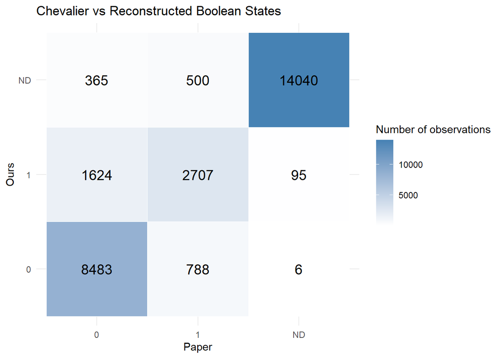

```r
ggplot(  # Start a plot of classification-category concordance.
  as.data.frame(confusion),  # Convert confusion-matrix counts to a data frame for plotting.
  aes(x = Paper, y = Ours, fill = Freq)  # Map paper category to x, our category to y, and count to fill.
) +  # Add the next plotting layer to the ggplot object.
  geom_tile(color = "white") +  # Draw a white-bordered square for each category pairing.
  geom_text(aes(label = Freq), size = 5) +  # Write each observation count inside its square.
  scale_fill_gradient(low = "white", high = "steelblue") +  # Encode low counts as white and higher counts as blue.
  theme_minimal() +  # Use a simple plot theme.
  labs(  # Set a descriptive plot title and legend text.
    title = "Chevalier vs Reconstructed Boolean States",  # Explain that the plot compares published and reconstructed states.
    fill = "Number of observations"  # Label the fill legend as an observation count.
  )  # Finish the axis and legend labels.
```

## 6.5 Quantify agreement and classification coverage

- **Three-state agreement:** fraction of all state–gene entries in the confusion-matrix diagonal; matching ND/ND counts as agreement.
- **Three-state Cohen’s kappa:** agreement corrected for what is expected from the category marginals.
- **Binary agreement (both determined):** agreement only among pairs where *both* methods assigned `0` or `1`; ND pairs are excluded.
- **Coverage:** proportion of non-ND entries in each method, irrespective of whether the values agree.

These statistics measure different properties: a high three-state agreement can coexist with low determination coverage if both methods frequently return ND.

```r
# Three-state percentage agreement
overall_agreement <- sum(diag(confusion)) / sum(confusion)  # Calculate the fraction of all entries on the confusion diagonal.

# Cohen's kappa including ND
observed <- overall_agreement  # Use that fraction as the observed agreement in kappa.

expected <- sum(  # Begin calculating agreement expected from category marginals.
  rowSums(confusion) * colSums(confusion)  # Multiply each paper row total by its corresponding column total.
) / sum(confusion)^2  # Normalize the expected count by squared total observations.

kappa_3state <- if (expected < 1) {  # Compute Cohen's kappa unless expected agreement is perfect.
  (observed - expected) / (1 - expected)  # Correct observed agreement for chance matching.
} else {  # Handle the degenerate case of expected agreement equal to one.
  NA_real_  # Return NA when kappa's denominator would be zero.
}  # Finish the kappa calculation.

# Compare only observations determined by both methods
both_determined <- !is.na(paper) & !is.na(ours)  # Identify entries where both methods assigned 0 or 1.

binary_agreement <- if (any(both_determined)) {  # Compute binary-only agreement if any shared determined pairs exist.
  mean(paper[both_determined] == ours[both_determined])  # Take the matching fraction across jointly determined pairs.
} else {  # Handle the case with zero jointly determined entries.
  NA_real_  # Return NA because binary agreement is then undefined.
}  # Finish calculating binary-only agreement.

# Coverage of both methods
paper_coverage <- mean(!is.na(paper))  # Compute the fraction of paper entries that are determined.
our_coverage <- mean(!is.na(ours))  # Compute the fraction of our entries that are determined.

data.frame(  # Begin assembling a human-readable metric summary.
  Metric = c(  # Start the metric-name vector.
    "Three-state agreement",  # Label overall three-category agreement.
    "Three-state Cohen's kappa",  # Label chance-adjusted three-category agreement.
    "Binary agreement (both determined)",  # Label agreement conditional on both values being determined.
    "Paper determined proportion",  # Label the published matrix's determination coverage.
    "Our determined proportion"  # Label the reconstructed matrix's determination coverage.
  ),  # Finish the list of metrics.
  Value = c(  # Start the corresponding numeric values.
    overall_agreement,  # Include overall three-state matching proportion.
    kappa_3state,  # Include Cohen's kappa.
    binary_agreement,  # Include conditional binary-only agreement.
    paper_coverage,  # Include coverage for the published profiles.
    our_coverage  # Include coverage for our profiles.
  )  # Finish the metric-values vector.
)  # Return the table of metrics and values.
```

```
##                               Metric     Value
## 1              Three-state agreement 0.8819211
## 2          Three-state Cohen's kappa 0.8039067
## 3 Binary agreement (both determined) 0.8226731
## 4        Paper determined proportion 0.5056977
## 5          Our determined proportion 0.4789919
```

# 7. Diagnose agreement by state and by gene

## 7.1 Compute per-state agreement

Build a cellwise Boolean indicator of agreement, considering `NA`/`NA` a match. For each STREAM state, report the fraction matching, number classified by each method, number classified by both, and number differing.

```r
# Equality matrix, treating two ND values as equal
same <- matrix(  # Begin building a logical state-by-gene agreement matrix.
  FALSE,  # Initialize each comparison as FALSE until proven equal.
  nrow = nrow(paper),  # Copy the number of STREAM states from paper.
  ncol = ncol(paper),  # Copy the number of comparable genes from paper.
  dimnames = dimnames(paper)  # Carry over state and gene identifiers.
)  # Finish initializing the agreement matrix.

same[is.na(paper) & is.na(ours)] <- TRUE  # Mark entries with ND in both matrices as matching.

both <- !is.na(paper) & !is.na(ours)  # Identify positions classified by both methods.

same[both] <- paper[both] == ours[both]  # Compare 0/1 values wherever both methods determined a call.

state_comparison <- data.frame(  # Begin summarizing agreement separately for each STREAM state.
  State = rownames(paper),  # Name each state using the aligned matrix's row labels.

  Agreement = rowMeans(same),  # Calculate the fraction of matching entries per state.

  Paper_Determined = rowSums(!is.na(paper)),  # Count determined genes in the paper for each state.

  Our_Determined = rowSums(!is.na(ours)),  # Count determined genes in our reconstruction for each state.

  Shared_Determined = rowSums(both),  # Count genes that both methods successfully determined.

  Different = rowSums(!same)  # Count genes whose classifications differ, including mismatched ND.
)  # Finish assembling the per-state comparison table.

state_comparison  # Display the state-level results.
```

```
##    State Agreement Paper_Determined Our_Determined Shared_Determined Different
## S1    S1 0.9282718             2415           2288              2272       342
## S4    S4 0.9381292             2435           2298              2296       295
## S0    S0 0.9232383             2330           2261              2258       366
## S2    S2 0.9190436             2476           2272              2271       386
## S5    S5 0.7369966             2362           2334              2261      1254
## S3    S3 0.8458473             2449           2250              2244       735
```

## 7.2 Plot agreement by STREAM state

Plot each state’s fraction of matching gene assignments (including matching ND values). The displayed y-axis spans 0 to 1, corresponding to 0–100% agreement.

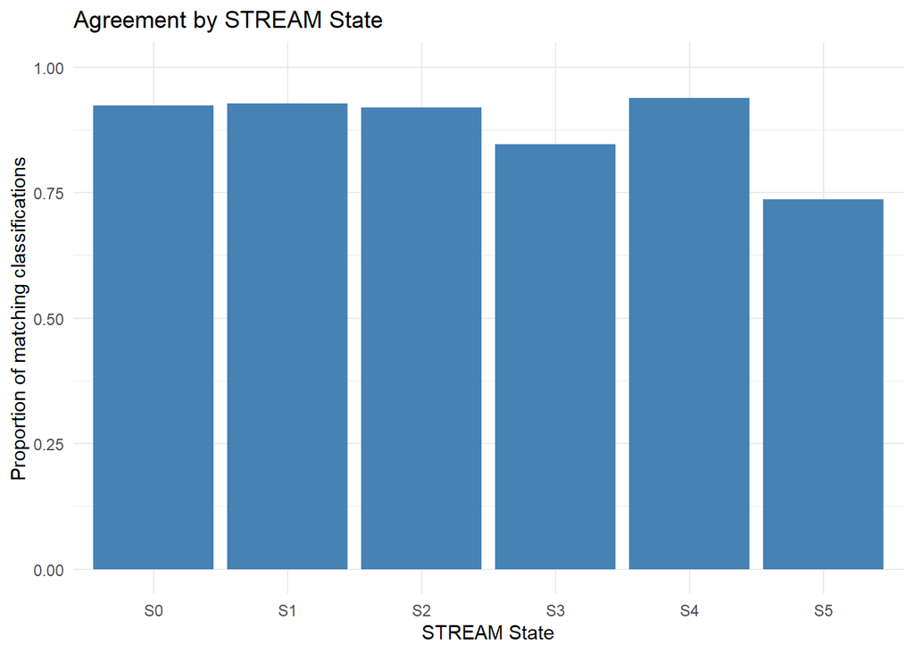

```r
ggplot(  # Begin plotting the state-specific agreement values.
  state_comparison,  # Use the per-state comparison table as the data source.
  aes(x = State, y = Agreement)  # Place state labels on x and agreement fraction on y.
) +  # Add the remaining plot layers to ggplot.
  geom_col(fill = "steelblue") +  # Draw one bar for each STREAM state's matching proportion.
  coord_cartesian(ylim = c(0, 1)) +  # Limit the visible agreement scale to 0–1.
  theme_minimal() +  # Apply a minimal plot theme.
  labs(  # Begin describing the title and both axes.
    title = "Agreement by STREAM State",  # Name this plot agreement by STREAM state.
    y = "Proportion of matching classifications",  # Explain the y-axis is a fraction of matching calls.
    x = "STREAM State"  # Label the x-axis with the STREAM state identifier.
  )  # Finish defining plot labels.
```

## 7.3 Identify genes with reproducible six-state profiles

For each gene, count matching states, calculate its proportion of matching states, check whether **all six** classifications match (including ND/ND), and count determined states in each method. Summarize the number and proportion of genes with exact reconstructed profiles.

```r
gene_comparison <- data.frame(  # Begin summarizing classification agreement per gene.
  Gene = colnames(paper),  # Copy comparable gene names from the matched matrices.

  Matching_States = colSums(same),  # Count how many STREAM states match for each gene.

  Agreement = colMeans(same),  # Compute the fraction of states matching for each gene.

  Exact_Match = colSums(same) == nrow(paper),  # Flag genes whose classifications match in every state.

  Paper_Determined = colSums(!is.na(paper)),  # Count determined states for each gene in the published data.

  Our_Determined = colSums(!is.na(ours))  # Count determined states for each gene in our reconstruction.
)  # Finish assembling the per-gene results.

# Number of genes with identical six-state profiles
sum(gene_comparison$Exact_Match)  # Count genes with exactly reproduced profiles across all states.
```

```
## [1] 2745
```

```r
# Percentage of genes perfectly replicated
mean(gene_comparison$Exact_Match)  # Calculate the proportion of exactly reproduced gene profiles.
```

```
## [1] 0.5757131
```

```r
# Gene-level summary
summary(gene_comparison$Agreement)  # Summarize the distribution of agreement rates over genes.
```

```
##    Min. 1st Qu.  Median    Mean 3rd Qu.    Max.
##  0.1667  0.8333  1.0000  0.8819  1.0000  1.0000
```

## 7.4 Inspect the least reproducible genes

Sort the per-gene agreement table ascending and display the 20 genes with the lowest agreement. These can be examined for distribution-related, threshold-related, or state-assignment differences..

```r
gene_comparison %>%  # Start a pipeline from the per-gene comparison table.
  arrange(Agreement) %>%  # Rank genes from least to most concordant across states.
  head(20)  # Display only the 20 genes with the lowest matching fractions.
```

```
##                        Gene Matching_States Agreement Exact_Match
## Cmtm6                 Cmtm6               1 0.1666667       FALSE
## Etnk1                 Etnk1               1 0.1666667       FALSE
## Grina                 Grina               1 0.1666667       FALSE
## H2-Q7                 H2-Q7               1 0.1666667       FALSE
## Irgm1                 Irgm1               1 0.1666667       FALSE
## Itgb1                 Itgb1               1 0.1666667       FALSE
## Kit                     Kit               1 0.1666667       FALSE
## Klf6                   Klf6               1 0.1666667       FALSE
## Malat1               Malat1               1 0.1666667       FALSE
## Mdm2                   Mdm2               1 0.1666667       FALSE
## Samhd1               Samhd1               1 0.1666667       FALSE
## Selplg               Selplg               1 0.1666667       FALSE
## 4632427E13Rik 4632427E13Rik               2 0.3333333       FALSE
## Abhd16a             Abhd16a               2 0.3333333       FALSE
## Ak3                     Ak3               2 0.3333333       FALSE
## Anapc4               Anapc4               2 0.3333333       FALSE
## Arhgdib             Arhgdib               2 0.3333333       FALSE
## Ash1l                 Ash1l               2 0.3333333       FALSE
## Atp2a3               Atp2a3               2 0.3333333       FALSE
## Ccng1                 Ccng1               2 0.3333333       FALSE
##               Paper_Determined Our_Determined
## Cmtm6                        6              5
## Etnk1                        6              6
## Grina                        6              6
## H2-Q7                        5              0
## Irgm1                        6              6
## Itgb1                        5              0
## Kit                          5              0
## Klf6                         5              0
## Malat1                       5              0
## Mdm2                         5              6
## Samhd1                       6              5
## Selplg                       5              0
## 4632427E13Rik                6              4
## Abhd16a                      6              5
## Ak3                          6              6
## Anapc4                       6              6
## Arhgdib                      3              1
## Ash1l                        5              5
## Atp2a3                       6              5
## Ccng1                        6              5
```

# 8. Estimate uncertainty by gene-level bootstrap

Resample columns (genes) of the aligned matrices **with replacement** 1,000 times. Within each resample, compute binary agreement among entries determined by both methods. The 2.5th and 97.5th bootstrap percentiles describe uncertainty under **gene-level resampling**, not a resampling of independent patients or cells.

**Output:** the lower percentile, median, and upper percentile of bootstrapped binary agreement. The fixed random seed makes this analysis reproducible.

```r
set.seed(123)  # Fix the random seed so bootstrap results can be reproduced.

boot_agreement <- replicate(1000, {  # Run 1,000 gene-level bootstrap replicates of binary agreement.

  sampled <- sample(  # Begin sampling gene-column indices with replacement.
    seq_len(ncol(paper)),  # Generate indices covering all shared gene columns.
    replace = TRUE  # Allow the same gene to be selected more than once.
  )  # Finish sampling one replicate of gene indices.

  p <- paper[, sampled, drop = FALSE]  # Subset the published matrix to bootstrap-selected genes.
  o <- ours[, sampled, drop = FALSE]  # Subset the reconstructed matrix using identical sampled genes.

  valid <- !is.na(p) & !is.na(o)  # Find entries determined by both methods in the resample.

  if (!any(valid)) {  # Check whether this resample contains any jointly determined entries.
    NA_real_  # Return missing agreement if there are no eligible entries.
  } else {  # Otherwise compute binary agreement for this resample.
    mean(p[valid] == o[valid])  # Calculate the matching fraction among jointly determined entries.
  }  # Finish the conditional binary-agreement calculation.
})  # Finish all 1,000 bootstrap replicates.

quantile(  # Begin extracting percentile summaries from bootstrap values.
  boot_agreement,  # Supply the replicate agreement values.
  c(0.025, 0.5, 0.975),  # Select the 2.5th, 50th, and 97.5th percentiles.
  na.rm = TRUE  # Exclude missing replicates if any occur.
)  # Finish computing the bootstrap percentile summary.
```

```
##      2.5%       50%     97.5%
## 0.8156884 0.8227025 0.8295230
```